# Proyect

Cristopher Barrios, Elean Rivas, Angel Higueros, Mariana David

16/2/2023

librerias

```r
library(haven)
library(stats)
library(dplyr)
library(ggplot2)
library(cluster) #Para calcular la silueta
library(e1071)#para cmeans
library(mclust) #mixtures of gaussians
library(fpc) #para hacer el plotcluster
library(NbClust) #Para determinar el número de clusters óptimo
library(factoextra) #Para hacer gráficos bonitos de clustering
library(hopkins) #Para revisar si vale la pena hacer agrupamiento
library(GGally) #Para hacer el conjunto de graficos
library(FeatureImpCluster) #Para revisar la importancia de las variables en los grupos. # nolint
library(pheatmap) #Para hacer mapa de calor
```

datos

```r
M2009 <- read_sav("Matrimonios/Matrimonio2009.sav") # nolint
M2010 <- read_sav("Matrimonios/Matrimonio2010.sav") # nolint
M2011 <- read_sav("Matrimonios/Matrimonio2011.sav") # nolint
M2012 <- read_sav("Matrimonios/Matrimonio2012.sav") # nolint
M2013 <- read_sav("Matrimonios/Matrimonio2013.sav") # nolint
M2014 <- read_sav("Matrimonios/Matrimonio2014.sav") # nolint
M2015 <- read_sav("Matrimonios/Matrimonio2015.sav") # nolint
M2016 <- read_sav("Matrimonios/Matrimonio2016.sav") # nolint
M2017 <- read_sav("Matrimonios/Matrimonio2017.sav") # nolint
M2018 <- read_sav("Matrimonios/Matrimonio2018.sav") # nolint
M2019 <- read_sav("Matrimonios/Matrimonio2019.sav") # nolint
M2020 <- read_sav("Matrimonios/Matrimonio2020.sav") # nolint
M2021 <- read_sav("Matrimonios/Matrimonio2021.sav") # nolint
```

Nacimiento

```r
N2009 <- read_sav("Nacimientos/Nacimiento2009.sav") # nolint
N2010 <- read_sav("Nacimientos/Nacimiento2010.sav") # nolint
N2011 <- read_sav("Nacimientos/Nacimiento2011.sav") # nolint
N2012 <- read_sav("Nacimientos/Nacimiento2012.sav") # nolint
N2013 <- read_sav("Nacimientos/Nacimiento2013.sav") # nolint
N2014 <- read_sav("Nacimientos/Nacimiento2014.sav") # nolint
N2015 <- read_sav("Nacimientos/Nacimiento2015.sav") # nolint
N2016 <- read_sav("Nacimientos/Nacimiento2016.sav") # nolint
N2017 <- read_sav("Nacimientos/Nacimiento2017.sav") # nolint
N2018 <- read_sav("Nacimientos/Nacimiento2018.sav") # nolint
N2019 <- read_sav("Nacimientos/Nacimiento2019.sav") # nolint
N2020 <- read_sav("Nacimientos/Nacimiento2020.sav") # nolint
N2021 <- read_sav("Nacimientos/Nacimiento2021.sav") # nolint
```

Divorcios

```r
D2009 <- read_sav("Divorcios/Divorcio2009.sav") # nolint
D2010 <- read_sav("Divorcios/Divorcio2010.sav") # nolint
D2011 <- read_sav("Divorcios/Divorcio2011.sav") # nolint
D2012 <- read_sav("Divorcios/Divorcio2012.sav") # nolint
D2013 <- read_sav("Divorcios/Divorcio2013.sav") # nolint
D2014 <- read_sav("Divorcios/Divorcio2014.sav") # nolint
D2015 <- read_sav("Divorcios/Divorcio2015.sav") # nolint
D2016 <- read_sav("Divorcios/Divorcio2016.sav") # nolint
D2017 <- read_sav("Divorcios/Divorcio2017.sav") # nolint
D2018 <- read_sav("Divorcios/Divorcio2018.sav") # nolint
D2019 <- read_sav("Divorcios/Divorcio2019.sav") # nolint
D2020 <- read_sav("Divorcios/Divorcio2020.sav") # nolint
D2021 <- read_sav("Divorcios/Divorcio2021.sav") # nolint
```

## Descripción variables y observaciones

Comience describiendo cuantas variables y observaciones tiene disponibles, el tipo de cada una de las variables.

## Resumen de datos

Haga un resumen de las variables numéricas e investigue si siguen una distribución normal y tablas de frecuencia para las variables categóricas, escriba lo que vaya encontrando.

```r
#summary(M2009)
# Crear una lista con los conjuntos de datos
datasets <- list(D2009, D2010, D2011, D2012, D2013, D2014, D2015, D2016, D2017, D2018, D2019, D2020, D2021)

# Crear un bucle for para analizar cada conjunto de datos y obtener los nombres de las variables numéricas
for (i in 1:length(datasets)) {
  vars_numéricas <- sapply(datasets[[i]], is.numeric)
  print(names(vars_numéricas[vars_numéricas]))
}
```

```
##  [1] "Depreg"  "Mesreg"  "Diaocu"  "Mesocu"  "Depocu"  "Edadhom" "Edadmuj"
##  [8] "Gethom"  "Getmuj"  "Nachom"  "Nacmuj"  "Ocuhom"  "Ocumuj"  "Mever"
## [15] "Anover"
##  [1] "depreg"   "mesreg"   "añoreg"   "diaocu"   "mesocu"   "añoocu"
##  [7] "depocu"   "edadhom"  "edadmuj"  "grethom"  "gretmuj"  "nachom"
## [13] "nacmuj"   "escohom"  "escomuj"  "ocupahom" "ocupamuj"
##  [1] "depreg"   "mesreg"   "añoreg"   "diaocu"   "mesocu"   "añoocu"
##  [7] "depocu"   "edadhom"  "edadmuj"  "grethom"  "gretmuj"  "nachom"
## [13] "nacmuj"   "escohom"  "escomuj"  "ocupahom" "ocupamuj"
##  [1] "DEPREG"  "MESREG"  "AÑOREG"  "DIAOCU"  "MESOCU"  "DEPOCU"  "EDADHOM"
##  [8] "EDADMUJ" "GETHOM"  "GETMUJ"  "NACHOM"  "NACMUJ"  "ESCHOM"  "ESCMUJ"
##  [1] "DEPREG"  "MESREG"  "AÑOREG"  "DIAOCU"  "MESOCU"  "DEPOCU"  "EDADHOM"
##  [8] "EDADMUJ" "PUEHOM"  "PUEMUJ"  "NACHOM"  "NACMUJ"  "ESCHOM"  "ESCMUJ"
##  [1] "DEPREG"  "MESREG"  "AÑOREG"  "DIAOCU"  "MESOCU"  "DEPOCU"  "EDADHOM"
##  [8] "EDADMUJ" "PUEHOM"  "PUEMUJ"  "NACHOM"  "NACMUJ"  "ESCHOM"  "ESCMUJ"
```

[output cut: 21 more lines]

## Variables importantes

Cruce las variables que considere que son las más importantes para hallar los elementos clave que lo pueden llevar a comprender lo que está causando el problema encontrado.

Tiempo: Es importante poder ver el cambio a través del tiempo, si ha habido un incremente o decremento, tanto en matrimonios como en divorcios

NUNUHO:“Número de nupcias del hombre” NUNUMU:“Número de nupcias de la mujer”

```r
M2021[, c(7, 8)]
```

```
## # A tibble: 87,480 × 2
##    NUNUHO       NUNUMU
##    <dbl+lbl>    <dbl+lbl>
##  1 9 [Ignorado] 9 [Ignorado]
##  2 1            1
##  3 9 [Ignorado] 9 [Ignorado]
##  4 1            1
##  5 9 [Ignorado] 9 [Ignorado]
##  6 9 [Ignorado] 9 [Ignorado]
##  7 9 [Ignorado] 9 [Ignorado]
##  8 1            1
##  9 9 [Ignorado] 9 [Ignorado]
## 10 9 [Ignorado] 9 [Ignorado]
## # ℹ 87,470 more rows
```

Saber si una persona ha estado previamente casada y si esto influye en la posibilidad de divorcio, cómo hipotesis se espera que las personas que han tenido más de dos nupcias antes, son más propensas al divorcio

Edadhom: “Edad del hombre” Edadmuj: “Edad de la mujer”

```r
D2021[, c(10, 11)]
```

```
## # A tibble: 9,621 × 2
##    EDADHOM        EDADMUJ
##    <dbl+lbl>      <dbl+lbl>
##  1  29             25
##  2  36             37
##  3  34             31
##  4  48             33
##  5  44             28
##  6  39             27
##  7  45             40
##  8 999 [Ignorado] 999 [Ignorado]
##  9  36             31
## 10 999 [Ignorado] 999 [Ignorado]
## # ℹ 9,611 more rows
```

La edad puede ser un dato interesante a explorar, esto para saber si los jovenes tienen más tendencia a casarse o divorcioarse y si los matrimonios más duraderos tienen menos divorcios

Genero: Es interesante ver que genero es más propenso a los divorcios, esto también puede estar relacionado con la cantidad de nupcias de una persona

Efectos de la pandemia: Ver como los divorcios y matrimonios se comportaron a partir de marzo de 2020 que fue el momento en que la cuarentena empezó a hacerse efectiva

## Graficos exploratorios

Haga gráficos exploratorios que le de ideas del estado de los datos.

## Analisis

## Divorcios

`r EdadMujD2009 <- sum(D2009$Edadmuj) EdadMujD2010 <- sum(D2010$edadmuj) EdadMujD2011 <- sum(D2011$edadmuj) EdadMujD2012 <- sum(D2012$EDADMUJ) EdadMujD2013 <- sum(D2013$EDADMUJ) EdadMujD2014 <- sum(D2014$EDADMUJ) EdadMujD2015 <- sum(D2015$EDADMUJ) EdadMujD2016 <- sum(D2016$EDADMUJ) EdadMujD2017 <- sum(D2017$EDADMUJ) EdadMujD2018 <- sum(D2018$EDADMUJ) EdadMujD2019 <- sum(D2019$EDADMUJ) EdadMujD2020 <- sum(D2020$EDADMUJ) EdadMujD2021 <- sum(D2021$EDADMUJ)`

`r dfD <- data.frame (año = c("2009", "2010", "2011", "2012", "2013", "2014", "2015", "2016", "2017","2018","2019","2020","2021"), matrimonios = c(EdadMujD2009, EdadMujD2010, EdadMujD2011, EdadMujD2012, EdadMujD2013, EdadMujD2014, EdadMujD2015, EdadMujD2016, EdadMujD2017, EdadMujD2018, EdadMujD2019, EdadMujD2020, EdadMujD2021)) print(dfD)`

`## año matrimonios ## 1 2009 1173016 ## 2 2010 2764309 ## 3 2011 3086834 ## 4 2012 3512781 ## 5 2013 3572498 ## 6 2014 3342987 ## 7 2015 3251831 ## 8 2016 3064039 ## 9 2017 3042894 ## 10 2018 3062850 ## 11 2019 3933259 ## 12 2020 1687235 ## 13 2021 3733294`

`r ggplot(dfD, aes(x=año, y=matrimonios, group = 1)) + geom_point(size = 2, color = "green") + geom_line(color="green") + labs(x = "Año", y = "Divorcios", title = "Divorcios")`

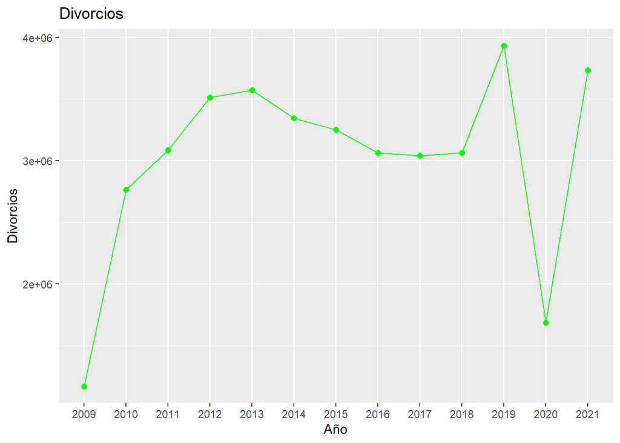

## Matrimonios

`r EdadMujM2009 <- sum(M2009$Edadmuj)`

`` ## Warning: Unknown or uninitialised column: `Edadmuj`. ``

`r EdadMujM2010 <- sum(M2010$edadmuj)`

`` ## Warning: Unknown or uninitialised column: `edadmuj`. ``

`r EdadMujM2011 <- sum(M2011$edadmuj)`

`` ## Warning: Unknown or uninitialised column: `edadmuj`. ``

`r EdadMujM2012 <- sum(M2012$EDADMUJ) EdadMujM2013 <- sum(M2013$EDADMUJ) EdadMujM2014 <- sum(M2014$EDADMUJ) EdadMujM2015 <- sum(M2015$EDADMUJ) EdadMujM2016 <- sum(M2016$EDADMUJ) EdadMujM2017 <- sum(M2017$EDADMUJ) EdadMujM2018 <- sum(M2018$EDADMUJ) EdadMujM2019 <- sum(M2019$EDADMUJ) EdadMujM2020 <- sum(M2020$EDADMUJ) EdadMujM2021 <- sum(M2021$EDADMUJ)`

`r dfD <- data.frame (año = c("2009", "2010", "2011", "2012", "2013", "2014", "2015", "2016", "2017","2018","2019","2020","2021"), matrimonios = c(EdadMujM2009, EdadMujM2010, EdadMujM2011, EdadMujM2012, EdadMujM2013, EdadMujM2014, EdadMujM2015, EdadMujM2016, EdadMujM2017, EdadMujM2018, EdadMujM2019, EdadMujM2020, EdadMujM2021)) print(dfD)`

`## año matrimonios ## 1 2009 0 ## 2 2010 0 ## 3 2011 0 ## 4 2012 2251360 ## 5 2013 2116792 ## 6 2014 2089815 ## 7 2015 2065832 ## 8 2016 1914942 ## 9 2017 1949642 ## 10 2018 2038355 ## 11 2019 2094080 ## 12 2020 1555747 ## 13 2021 2407251`

`r ggplot(dfD, aes(x=año, y=matrimonios, group = 1)) + geom_point(size = 2, color = "green") + geom_line(color="green") + labs(x = "Año", y = "Matrimonios", title = "Matrimonios")`

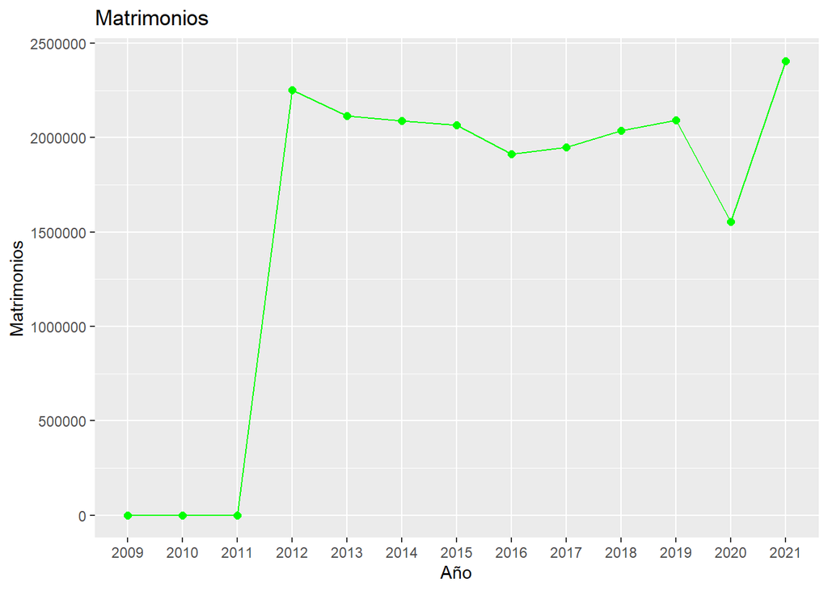

## Nacimientos

`r EdadMujN2009 <- sum(N2009$Edadm) EdadMujN2010 <- sum(N2010$Edadm) EdadMujN2011 <- sum(N2011$Edadm) EdadMujN2012 <- sum(N2012$Edadm) EdadMujN2013 <- sum(N2013$Edadm) EdadMujN2014 <- sum(N2014$Edadm) EdadMujN2015 <- sum(N2015$Edadm) EdadMujN2016 <- sum(N2016$Edadm) EdadMujN2017 <- sum(N2017$Edadm) EdadMujN2018 <- sum(N2018$Edadm) EdadMujN2019 <- sum(N2019$Edadm) EdadMujN2020 <- sum(N2020$Edadm) EdadMujN2021 <- sum(N2021$Edadm)`

`r dNac <- data.frame (año = c("2009", "2010", "2011", "2012", "2013", "2014", "2015", "2016", "2017","2018","2019","2020","2021"), matrimonios = c(EdadMujN2009, EdadMujN2010, EdadMujN2011, EdadMujN2012, EdadMujN2013, EdadMujN2014, EdadMujN2015, EdadMujN2016, EdadMujN2017, EdadMujN2018, EdadMujN2019, EdadMujN2020, EdadMujN2021)) print(dNac)`

`## año matrimonios ## 1 2009 20298288 ## 2 2010 9550498 ## 3 2011 9713100 ## 4 2012 9974089 ## 5 2013 10152809 ## 6 2014 10021535 ## 7 2015 10162460 ## 8 2016 10093076 ## 9 2017 9862143 ## 10 2018 9922821 ## 11 2019 9922821 ## 12 2020 9473381 ## 13 2021 8949596`

`r ggplot(dNac, aes(x=año, y=matrimonios, group = 1)) + geom_point(size = 2, color = "green") + geom_line(color="green") + labs(x = "Año", y = "Nacimientos", title = "Nacimientos")`

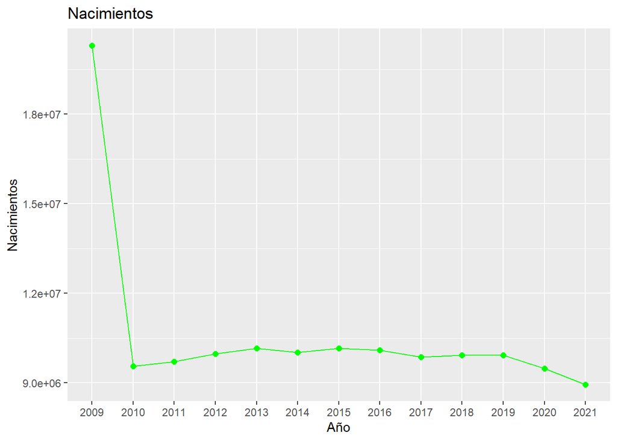

## Histogramas

2009

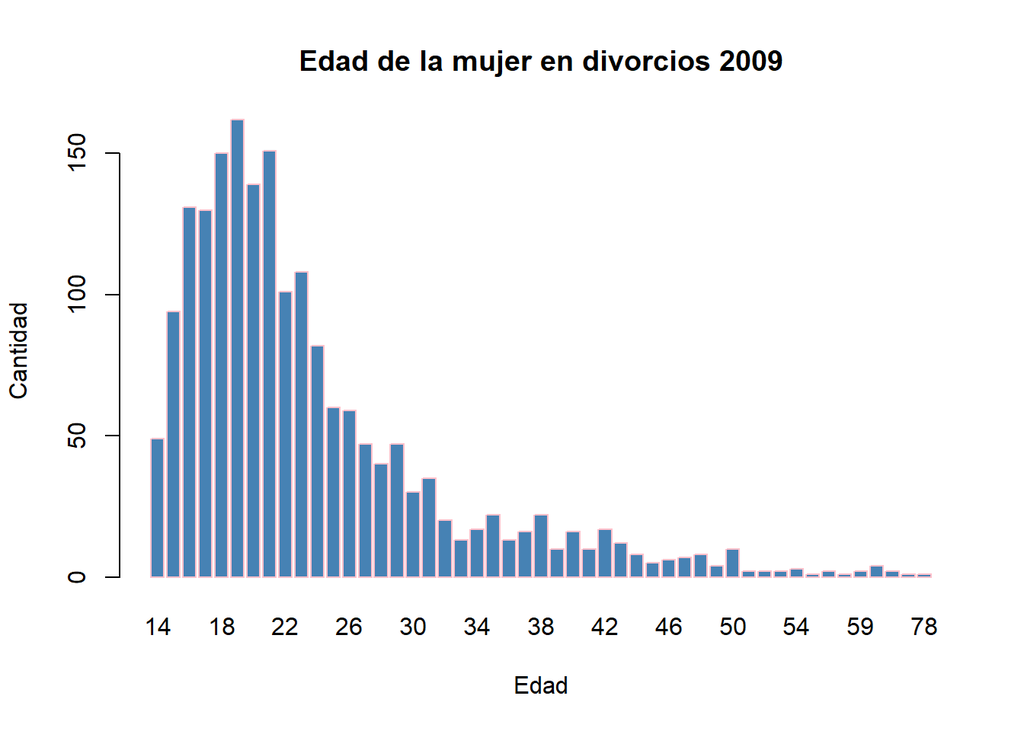

```r
library(dplyr)
library(ggplot2)

D2009 <- subset(D2009, Edadmuj < 999)

barplot(table(D2009$Edadmuj), main = "Edad de la mujer en divorcios 2009", xlab = "Edad", ylab = "Cantidad", col = "steelblue" , border = "pink")
```

2010

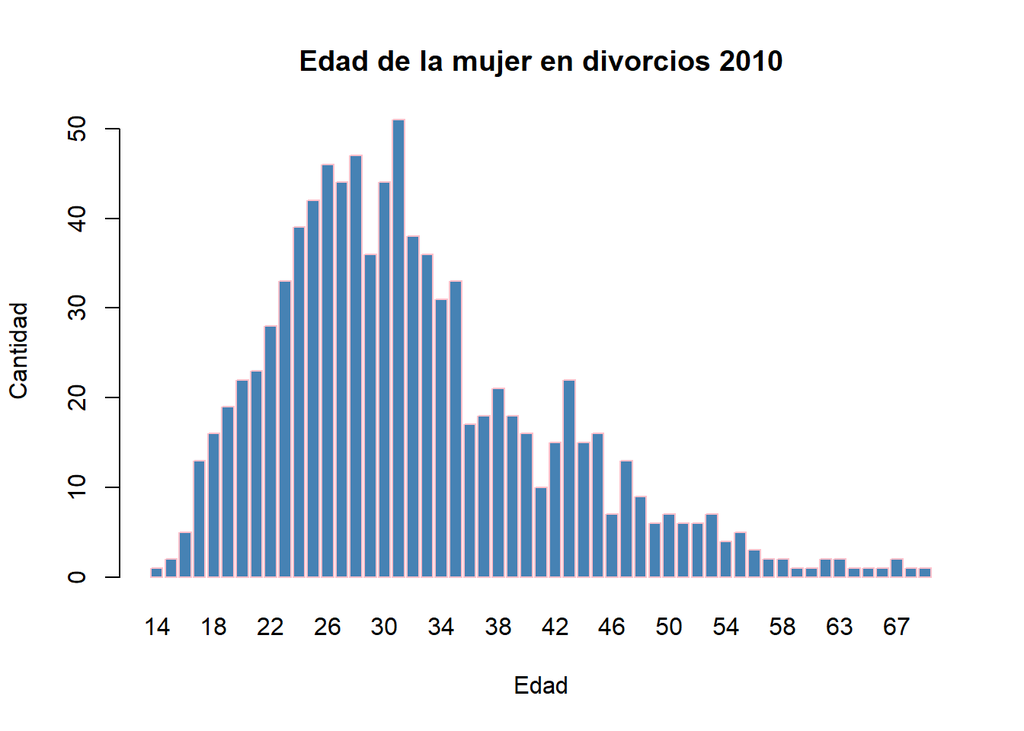

```r
D2010 <- subset(D2010, edadmuj < 999)

barplot(table(D2010$edadmuj), main = "Edad de la mujer en divorcios 2010", xlab = "Edad", ylab = "Cantidad", col = "steelblue" , border = "pink")
```

2011

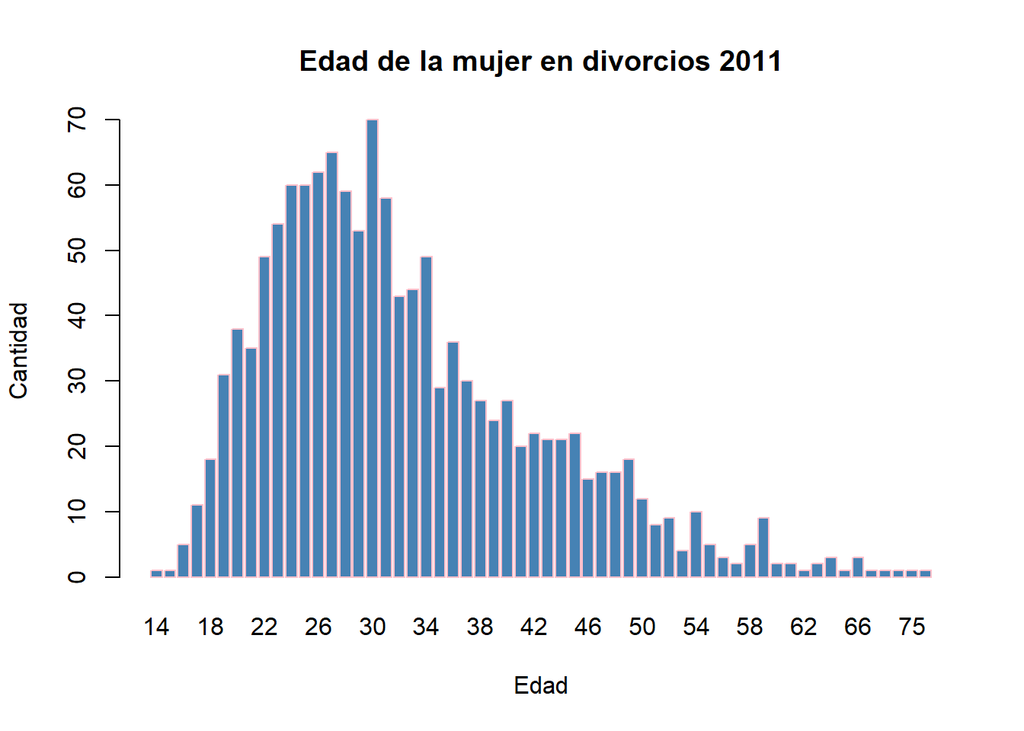

```r
D2011 <- subset(D2011, edadmuj < 999)

barplot(table(D2011$edadmuj), main = "Edad de la mujer en divorcios 2011", xlab = "Edad", ylab = "Cantidad", col = "steelblue" , border = "pink")
```

2012

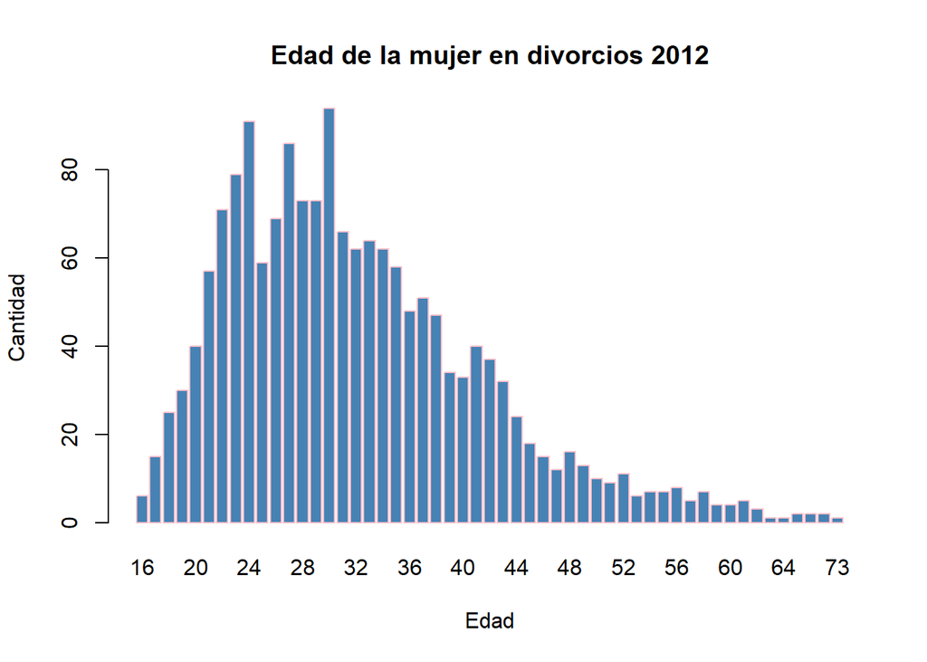

```r
D2012 <- subset(D2012, EDADMUJ < 999)

barplot(table(D2012$EDADMUJ), main = "Edad de la mujer en divorcios 2012", xlab = "Edad", ylab = "Cantidad", col = "steelblue" , border = "pink")
```

2013

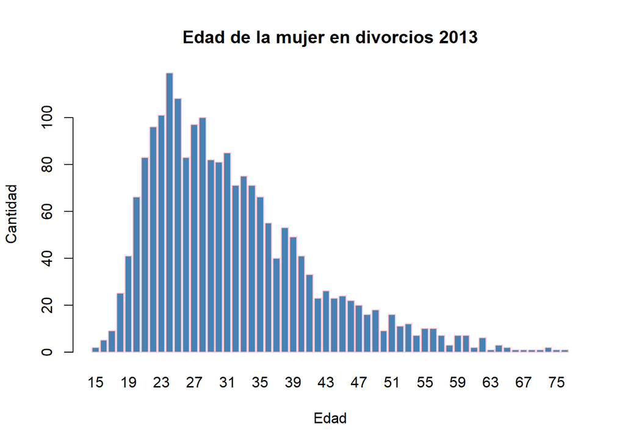

```r
D2013 <- subset(D2013, EDADMUJ < 999)

barplot(table(D2013$EDADMUJ), main = "Edad de la mujer en divorcios 2013", xlab = "Edad", ylab = "Cantidad", col = "steelblue" , border = "pink")
```

2014

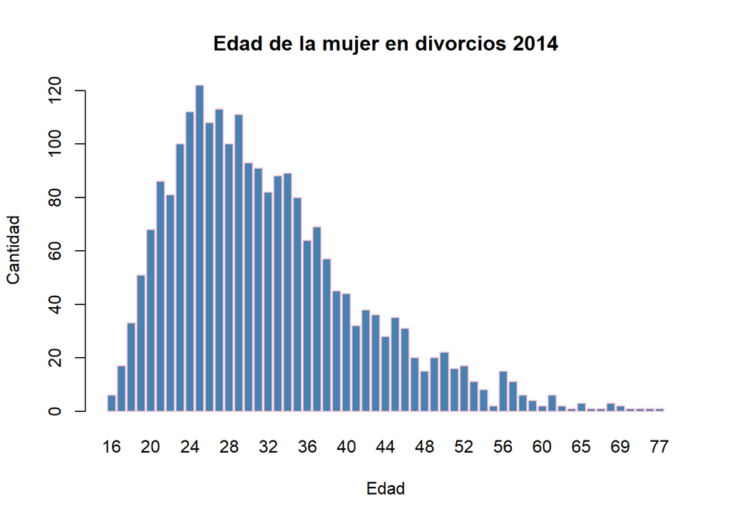

```r
D2014 <- subset(D2014, EDADMUJ < 999)

barplot(table(D2014$EDADMUJ), main = "Edad de la mujer en divorcios 2014", xlab = "Edad", ylab = "Cantidad", col = "steelblue" , border = "pink")
```

2015

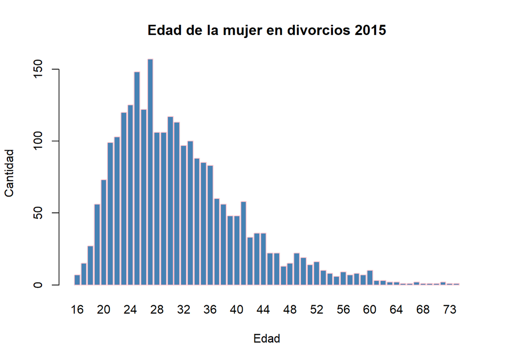

```r
D2015 <- subset(D2015, EDADMUJ < 999)

barplot(table(D2015$EDADMUJ), main = "Edad de la mujer en divorcios 2015", xlab = "Edad", ylab = "Cantidad", col = "steelblue" , border = "pink")
```

2016

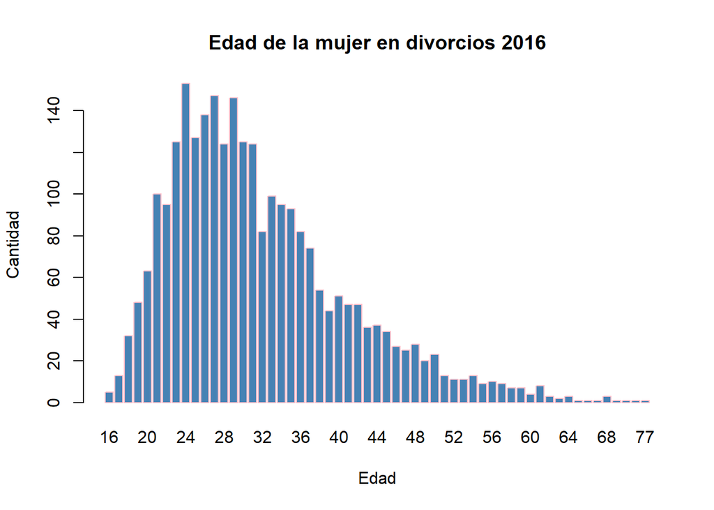

```r
D2016 <- subset(D2016, EDADMUJ < 999)

barplot(table(D2016$EDADMUJ), main = "Edad de la mujer en divorcios 2016", xlab = "Edad", ylab = "Cantidad", col = "steelblue" , border = "pink")
```

2017

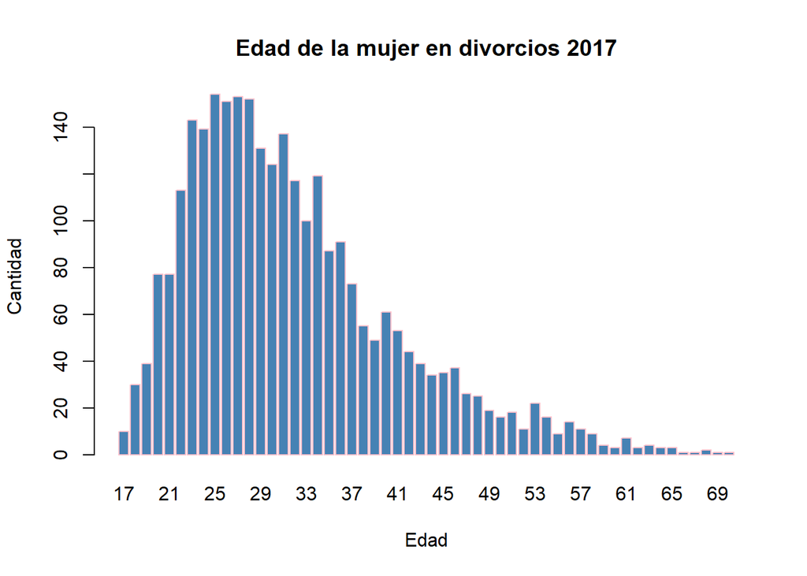

```r
D2017 <- subset(D2017, EDADMUJ < 999)

barplot(table(D2017$EDADMUJ), main = "Edad de la mujer en divorcios 2017", xlab = "Edad", ylab = "Cantidad", col = "steelblue" , border = "pink")
```

2018

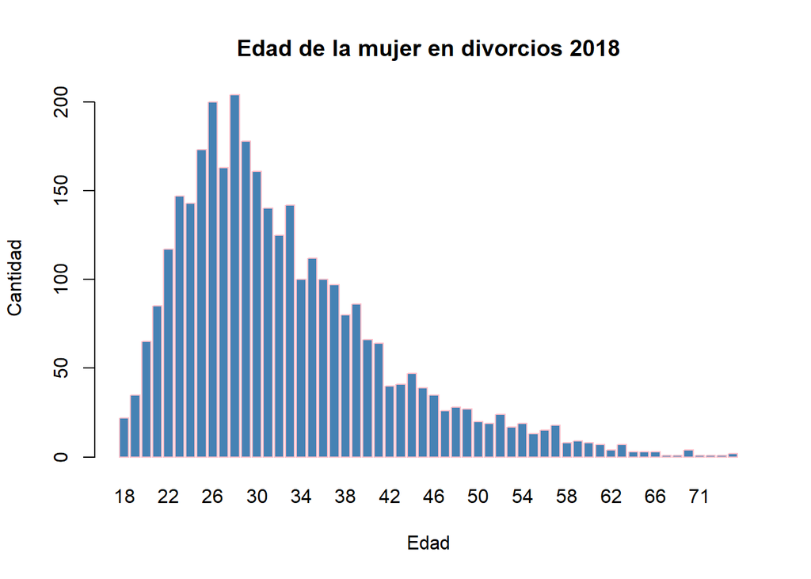

```r
D2018 <- subset(D2018, EDADMUJ < 999)

barplot(table(D2018$EDADMUJ), main = "Edad de la mujer en divorcios 2018", xlab = "Edad", ylab = "Cantidad", col = "steelblue" , border = "pink")
```

2019

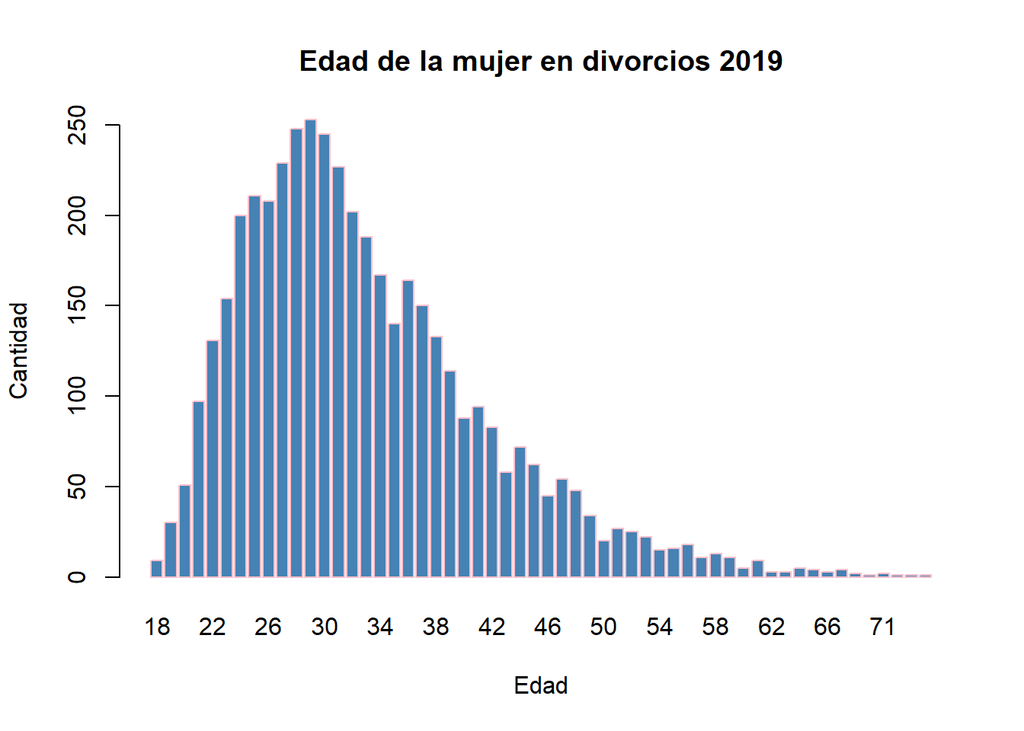

```r
D2019 <- subset(D2019, EDADMUJ < 999)

barplot(table(D2019$EDADMUJ), main = "Edad de la mujer en divorcios 2019", xlab = "Edad", ylab = "Cantidad", col = "steelblue" , border = "pink")
```

2020

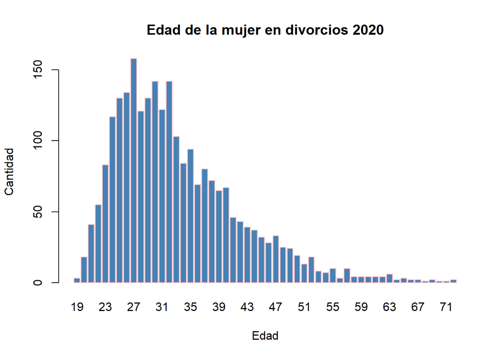

```r
D2020 <- subset(D2020, EDADMUJ < 999)

barplot(table(D2020$EDADMUJ), main = "Edad de la mujer en divorcios 2020", xlab = "Edad", ylab = "Cantidad", col = "steelblue" , border = "pink")
```

2021

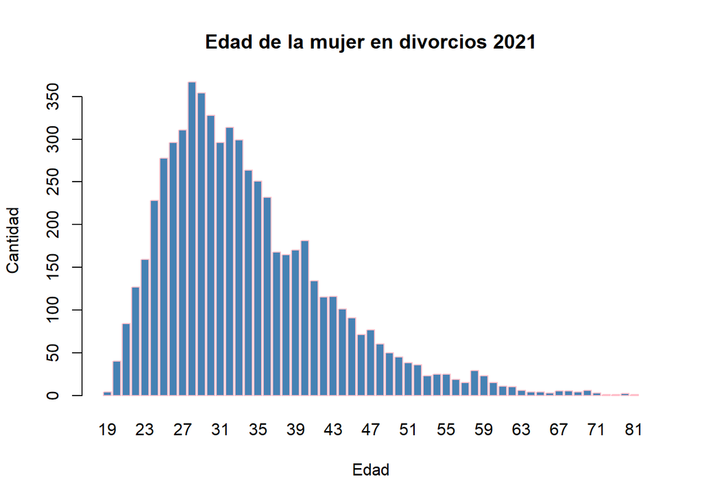

```r
D2021 <- subset(D2021, EDADMUJ < 999)

barplot(table(D2021$EDADMUJ), main = "Edad de la mujer en divorcios 2021", xlab = "Edad", ylab = "Cantidad", col = "steelblue" , border = "pink")
```

## Combinando datos

```r
colnames(D2009) <- c("DEPREG", "MUPREG", "MESREG", "AÑOREG", "DIAOCU", "MESOCU", "AÑOOCU", "DEPOCU", "MUPOCU", "EDADHOM", "EDADMUJ", "PPERHOM", "PPERMUJ", "NACHOM", "NACMUJ", "CIUOHOM", "CIUOMUJ", "Mever", "Anover")
colnames(D2010) <- c("DEPREG", "MUPREG", "MESREG", "AÑOREG", "DIAOCU", "MESOCU", "AÑOOCU", "DEPOCU", "MUPOCU", "EDADHOM", "EDADMUJ", "PPERHOM", "PPERMUJ", "NACHOM", "NACMUJ", "ESCHOM", "ESCMUJ", "CIUOHOM", "CIUOMUJ")
colnames(D2011) <- c("DEPREG", "MUPREG", "MESREG", "AÑOREG", "DIAOCU", "MESOCU", "AÑOOCU", "DEPOCU", "MUPOCU", "EDADHOM", "EDADMUJ", "PPERHOM", "PPERMUJ", "NACHOM", "NACMUJ", "ESCHOM", "ESCMUJ", "CIUOHOM", "CIUOMUJ")
colnames(D2012) <- c("DEPREG",  "MUPREG",  "MESREG",  "AÑOREG",  "DIAOCU",  "MESOCU",  "DEPOCU",  "MUPOCU", "EDADHOM", "EDADMUJ", "PPERHOM",  "PPERMUJ",  "NACHOM",  "NACMUJ",  "ESCHOM",  "ESCMUJ", "CIUOHOM",  "CIUOMUJ")
colnames(D2013) <- c( "DEPREG",  "MUPREG",  "MESREG",  "AÑOREG",  "DIAOCU",  "MESOCU",  "DEPOCU",  "MUPOCU",  "EDADHOM", "EDADMUJ", "PPERHOM",  "PPERMUJ",  "NACHOM",  "NACMUJ",  "ESCHOM",  "ESCMUJ",  "CIUOHOM", "CIUOMUJ")
colnames(D2014) <- c( "DEPREG",  "MUPREG",  "MESREG",  "AÑOREG",  "DIAOCU",  "MESOCU",  "DEPOCU",  "MUPOCU", "EDADHOM", "EDADMUJ", "PPERHOM",  "PPERMUJ",  "NACHOM",  "NACMUJ",  "ESCHOM",  "ESCMUJ",  "CIUOHOM", "CIUOMUJ")
colnames(D2015) <- c("DEPREG",  "MUPREG",  "MESREG",  "AÑOREG",  "DIAOCU",  "MESOCU",  "AÑOOCU",  "DEPOCU",  "MUPOCU",  "EDADHOM", "EDADMUJ", "PPERHOM", "PPERMUJ",  "NACHOM", "NACMUJ",  "ESCHOM",  "ESCMUJ",  "CIUOHOM", "CIUOMUJ")
```

```r
D2009 <- D2009 %>% mutate(AÑOREG = as.numeric(AÑOREG))
D2010 <- D2010 %>% mutate(AÑOREG = as.numeric(AÑOREG))
D2011 <- D2011 %>% mutate(AÑOREG = as.numeric(AÑOREG))
D2012 <- D2012 %>% mutate(AÑOREG = as.numeric(AÑOREG))
D2013 <- D2013 %>% mutate(AÑOREG = as.numeric(AÑOREG))
D2014 <- D2014 %>% mutate(AÑOREG = as.numeric(AÑOREG))
D2015 <- D2015 %>% mutate(AÑOREG = as.numeric(AÑOREG))
D2016 <- D2016 %>% mutate(AÑOREG = as.numeric(AÑOREG))
D2017 <- D2017 %>% mutate(AÑOREG = as.numeric(AÑOREG))
D2018 <- D2018 %>% mutate(AÑOREG = as.numeric(AÑOREG))
D2019 <- D2019 %>% mutate(AÑOREG = as.numeric(AÑOREG))
D2020 <- D2020 %>% mutate(AÑOREG = as.numeric(AÑOREG))
D2021 <- D2021 %>% mutate(AÑOREG = as.numeric(AÑOREG))
```

```r
D2009 <- D2009 %>% mutate(AÑOOCU = as.numeric(AÑOOCU))
D2010 <- D2010 %>% mutate(AÑOOCU = as.numeric(AÑOOCU))
D2011 <- D2011 %>% mutate(AÑOOCU = as.numeric(AÑOOCU))
```

```r
D2009 <- D2009 %>% mutate(CIUOHOM = as.character(CIUOHOM))
D2010 <- D2010 %>% mutate(CIUOHOM = as.character(CIUOHOM))
D2011 <- D2011 %>% mutate(CIUOHOM = as.character(CIUOHOM))
D2012 <- D2012 %>% mutate(CIUOHOM = as.character(CIUOHOM))
D2013 <- D2013 %>% mutate(CIUOHOM = as.character(CIUOHOM))
D2014 <- D2014 %>% mutate(CIUOHOM = as.character(CIUOHOM))
D2015 <- D2015 %>% mutate(CIUOHOM = as.character(CIUOHOM))
D2016 <- D2016 %>% mutate(CIUOHOM = as.character(CIUOHOM))
D2017 <- D2017 %>% mutate(CIUOHOM = as.character(CIUOHOM))
D2018 <- D2018 %>% mutate(CIUOHOM = as.character(CIUOHOM))
D2019 <- D2019 %>% mutate(CIUOHOM = as.character(CIUOHOM))
D2020 <- D2020 %>% mutate(CIUOHOM = as.character(CIUOHOM))
D2021 <- D2021 %>% mutate(CIUOHOM = as.character(CIUOHOM))
```

```r
D2009 <- D2009 %>% mutate(CIUOMUJ = as.character(CIUOMUJ))
D2010 <- D2010 %>% mutate(CIUOMUJ = as.character(CIUOMUJ))
D2011 <- D2011 %>% mutate(CIUOMUJ = as.character(CIUOMUJ))
D2012 <- D2012 %>% mutate(CIUOMUJ = as.character(CIUOMUJ))
D2013 <- D2013 %>% mutate(CIUOMUJ = as.character(CIUOMUJ))
D2014 <- D2014 %>% mutate(CIUOMUJ = as.character(CIUOMUJ))
D2015 <- D2015 %>% mutate(CIUOMUJ = as.character(CIUOMUJ))
D2016 <- D2016 %>% mutate(CIUOMUJ = as.character(CIUOMUJ))
D2017 <- D2017 %>% mutate(CIUOMUJ = as.character(CIUOMUJ))
D2018 <- D2018 %>% mutate(CIUOMUJ = as.character(CIUOMUJ))
D2019 <- D2019 %>% mutate(CIUOMUJ = as.character(CIUOMUJ))
D2020 <- D2020 %>% mutate(CIUOMUJ = as.character(CIUOMUJ))
D2021 <- D2021 %>% mutate(CIUOMUJ = as.character(CIUOMUJ))
```

```r
#divorcios <- bind_rows(D2009, D2010, D2011, D2012, D2013, D2014, D2015, D2016, D2017, D2018, D2019, D2020, D2021)
divorcios <- bind_rows( D2012, D2013, D2014, D2015, D2016, D2017, D2018, D2019, D2020, D2021)
#l = list(D2012, D2013, D2014, D2015, D2016, D2017, D2018, D2019, D2020, D2021)
#divorcios <- do.call("rbind",l)
```

```r
str(divorcios)
```

```
## tibble [30,378 × 19] (S3: tbl_df/tbl/data.frame)
##  $ DEPREG : dbl+lbl [1:30378] 17, 12,  1, 14,  1,  1,  1,  1,  1,  1,  9, 22,  3, ...
##    ..@ labels: Named num [1:22] 1 2 3 4 5 6 7 8 9 10 ...
##    .. ..- attr(*, "names")= chr [1:22] "Guatemala" "El Progreso" "Sacatepequez" "Chimaltenango" ...
##    ..@ label : chr "Departamento de registro"
##  $ MUPREG : chr+lbl [1:30378] 1708, 1213, 0101, 1416, 0101, 0101, 0101, 0101, 0101...
##    ..@ labels: Named chr [1:342] "1010" "2010" "0110" "1210" ...
##    .. ..- attr(*, "names")= chr [1:342] "San Antonio Suchitepéquez" "San Jacinto" "San Juan Sacatepéquez" "Tejutla" ...
##    ..@ label : chr "Municipio de registro"
##  $ MESREG : dbl+lbl [1:30378]  3,  5,  4,  6, 10,  2,  8, 11,  9,  8,  4,  1,  4, ...
##    ..@ labels: Named num [1:12] 1 2 3 4 5 6 7 8 9 10 ...
##    .. ..- attr(*, "names")= chr [1:12] "Enero" "Febrero" "Marzo" "Abril" ...
##    ..@ label : chr "Mes de registro"
##  $ AÑOREG : num [1:30378] 2012 2012 2012 2012 2012 ...
##  $ DIAOCU : num [1:30378] 16 3 27 28 12 9 11 3 29 16 ...
##  $ MESOCU : dbl+lbl [1:30378]  2,  2,  3,  5,  3,  1,  6,  8,  2,  5,  5,  2,  4, ...
##    ..@ label      : chr "Mes de ocurrencia"
##    ..@ format.spss: chr "F2.0"
##    ..@ labels     : Named num [1:12] 1 2 3 4 5 6 7 8 9 10 ...
##    .. ..- attr(*, "names")= chr [1:12] "Enero" "Febrero" "Marzo" "Abril" ...
##  $ DEPOCU : dbl+lbl [1:30378] 17, 12,  1, 14,  1,  1,  1,  1,  1,  1,  9, 22,  1, ...
##    ..@ labels: Named num [1:22] 1 2 3 4 5 6 7 8 9 10 ...
##    .. ..- attr(*, "names")= chr [1:22] "Guatemala" "El Progreso" "Sacatepequez" "Chimaltenango" ...
##    ..@ label : chr "Departamento de ocurrencia"
##  $ MUPOCU : chr+lbl [1:30378] 1703, 1215, 0101, 1401, 0101, 0101, 0101, 0101, 0101...
##    ..@ labels: Named chr [1:342] "1010" "2010" "0110" "1210" ...
##    .. ..- attr(*, "names")= chr [1:342] "San Antonio Suchitepéquez" "San Jacinto" "San Juan Sacatepéquez" "Tejutla" ...
##    ..@ label : chr "Municipio de ocurrencia"
##  $ EDADHOM: dbl+lbl [1:30378] 999,  35,  33,  31,  27,  37,  41,  36,  46,  38,  3...
##    ..@ label      : chr "Edad del hombre"
##    ..@ format.spss: chr "F4.0"
##    ..@ labels     : Named num 999
##    .. ..- attr(*, "names")= chr "Ignorado"
##  $ EDADMUJ: dbl+lbl [1:30378] 33, 30, 32, 28, 29, 30, 42, 30, 37, 35, 35, 33, 38, ...
##    ..@ label      : chr "Edad de la mujer"
##    ..@ format.spss: chr "F4.0"
##    ..@ labels     : Named num 999
##    .. ..- attr(*, "names")= chr "Ignorado"
##  $ PPERHOM: dbl+lbl [1:30378] 9, 2, 9, 9, 2, 9, 2, 2, 2, 2, 1, 9, 2, 2, 1, 2, 2, 9...
##    ..@ labels: Named num [1:6] 1 2 9 3 4 5
```

[output cut: 10 more lines]

```
##  $ NACMUJ : dbl+lbl [1:30378] 320, 320, 320, 320, 320, 320, 320, 320, 320, 320, 32...
##    ..@ labels: Named num [1:103] 76 84 170 188 192 218 222 276 320 340 ...
##    .. ..- attr(*, "names")= chr [1:103] "Brasil" "Belice" "Colombia" "Costa Rica" ...
##    ..@ label : chr "Nacionalidad de la mujer"
##  $ ESCHOM : dbl+lbl [1:30378] 9, 5, 5, 1, 4, 9, 5, 5, 5, 9, 4, 9, 3, 5, 9, 9, 3, 9...
##    ..@ labels: Named num [1:8] 1 2 3 4 5 9 6 0
##    .. ..- attr(*, "names")= chr [1:8] "Ninguna" "Primaria" "Básico" "Diversificado" ...
##    ..@ label : chr "Escolaridad del hombre"
##  $ ESCMUJ : dbl+lbl [1:30378] 4, 9, 5, 4, 5, 9, 5, 5, 5, 5, 4, 4, 4, 5, 4, 5, 5, 9...
##    ..@ labels: Named num [1:8] 1 2 3 4 5 9 6 0
##    .. ..- attr(*, "names")= chr [1:8] "Ninguna" "Primaria" "Básico" "Diversificado" ...
##    ..@ label : chr "Escolaridad de la mujer"
##  $ CIUOHOM: chr [1:30378] "9712" "110" "2142" "8189" ...
##  $ CIUOMUJ: chr [1:30378] "110" "1120" "1120" "1120" ...
##  $ AÑOOCU : num [1:30378] NA NA NA NA NA NA NA NA NA NA ...
```

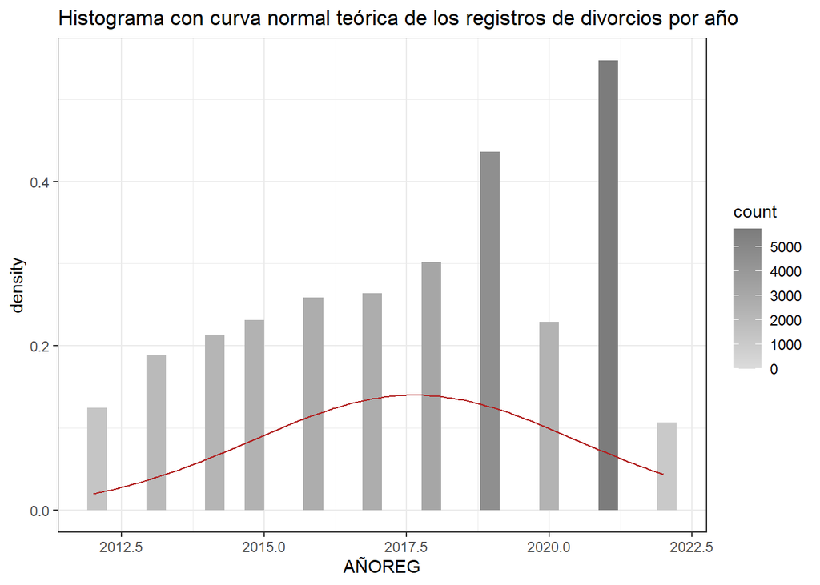

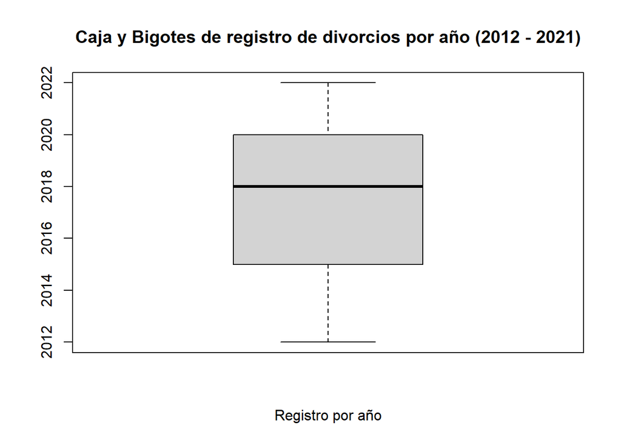

```r
boxplot(divorcios$AÑOREG, main = "Caja y Bigotes de registro de divorcios por año (2012 - 2021)", xlab = "Registro por año")
```

### Diagrama de qqnormal

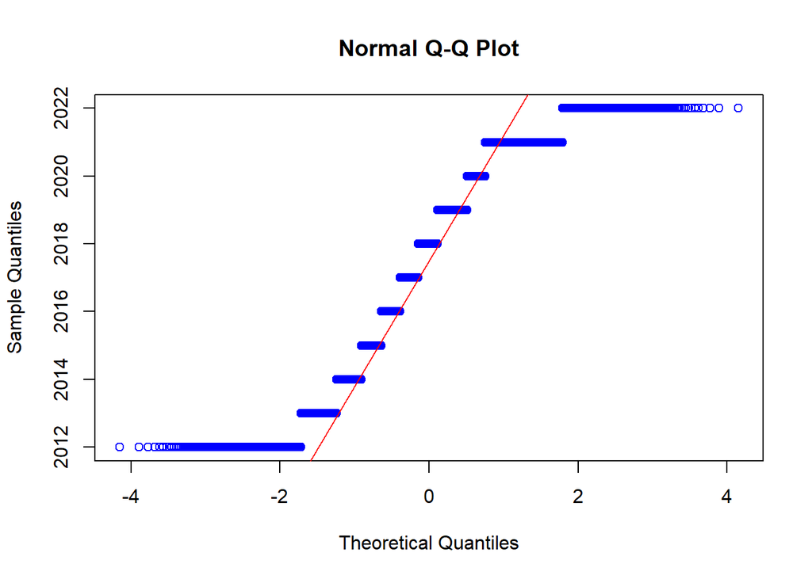

## Registros de Edad hombre

### Prueba de normalidad para la edad del hombre:

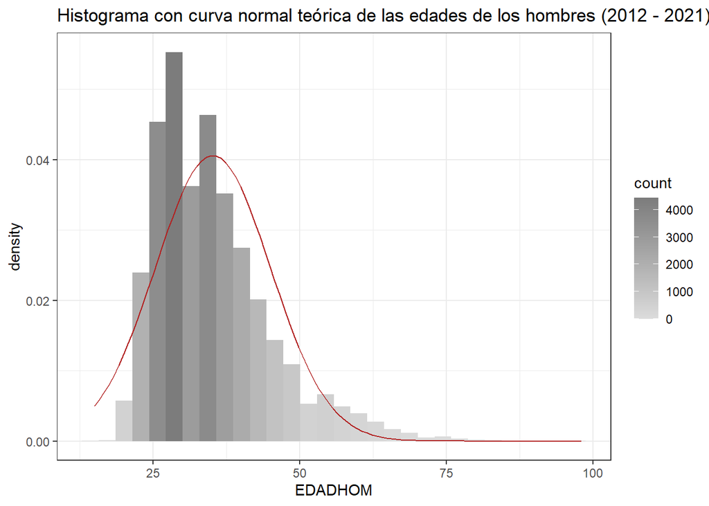

### Diagrama de caja y bigotes

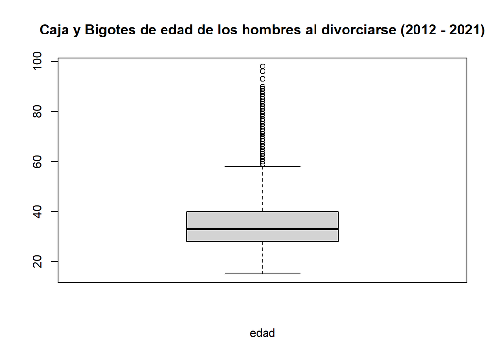

### Diagrama qqnormal

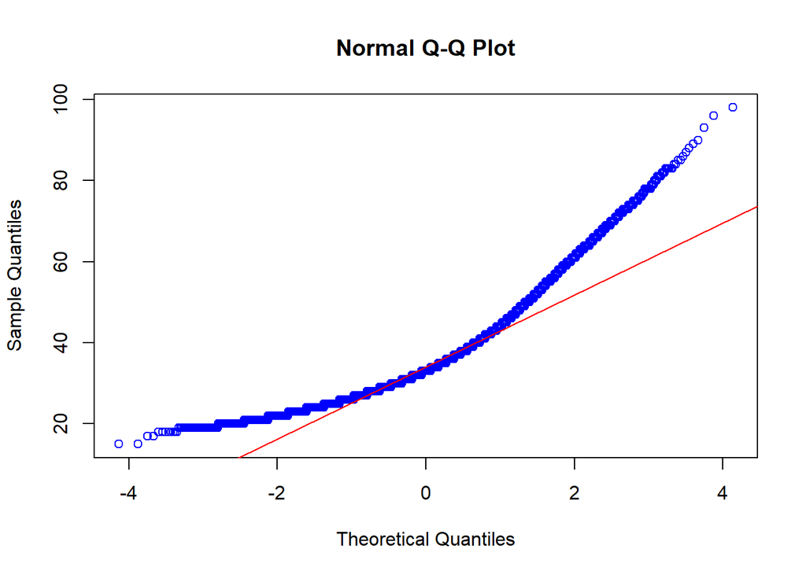

## Registros de edad de mujeres

### Prueba de normalidad para la edad de la mujer:

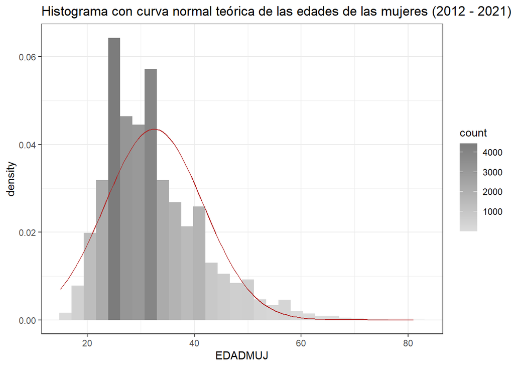

### Diagrama de caja y bigotes

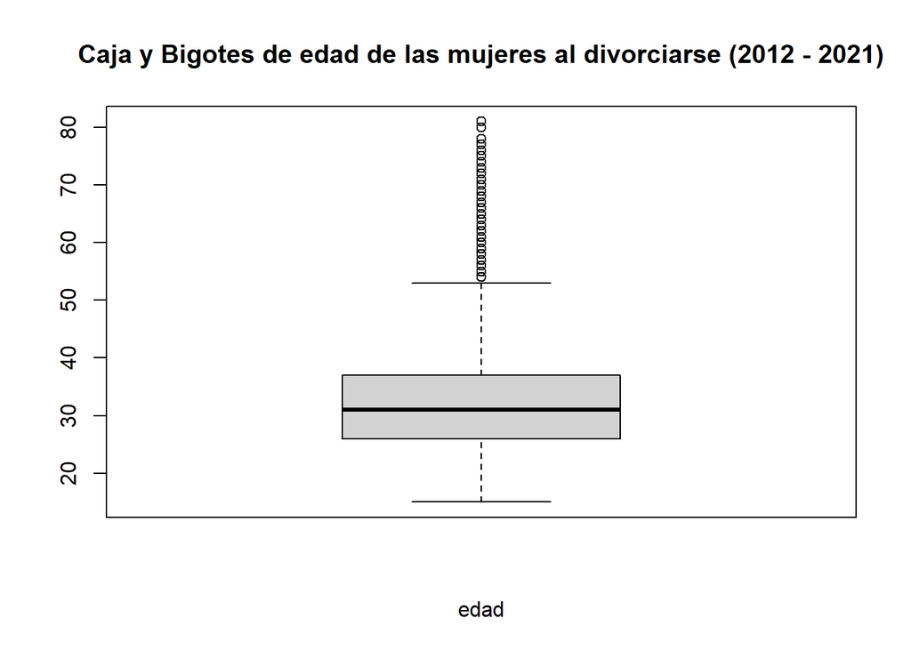

### Diagrama qqnormal

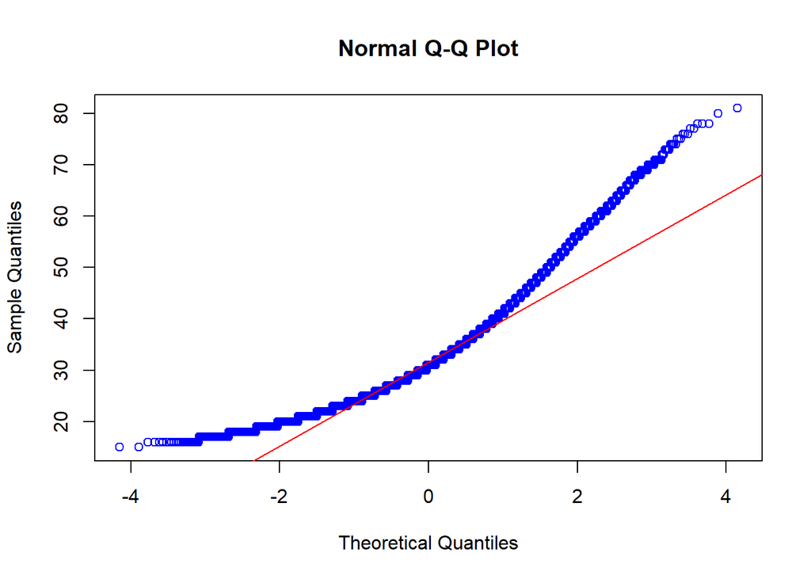

## Tabla de frecuencias para variables cualitativas

### Tabla de frecuencias para el departamento de ocurrencia y representación gráfica

```r
D2009 <- D2009 %>%
  mutate_if(is.labelled,list(as_factor))
D2010 <- D2010 %>%
  mutate_if(is.labelled,list(as_factor))
D2011 <- D2011 %>%
  mutate_if(is.labelled,list(as_factor))
D2012 <- D2012 %>%
  mutate_if(is.labelled,list(as_factor))
D2013 <- D2013 %>%
  mutate_if(is.labelled,list(as_factor))
D2014 <- D2014 %>%
  mutate_if(is.labelled,list(as_factor))
D2015 <- D2015 %>%
  mutate_if(is.labelled,list(as_factor))
D2016 <- D2016 %>%
  mutate_if(is.labelled,list(as_factor))
D2017 <- D2017 %>%
  mutate_if(is.labelled,list(as_factor))
D2018 <- D2018 %>%
  mutate_if(is.labelled,list(as_factor))
D2019 <- D2019 %>%
  mutate_if(is.labelled,list(as_factor))
D2020 <- D2020 %>%
  mutate_if(is.labelled,list(as_factor))
D2021 <- D2021 %>%
  mutate_if(is.labelled,list(as_factor))

divorciosLabels <- bind_rows( D2012, D2013, D2014, D2015, D2016, D2017, D2018, D2019, D2020, D2021)
```

```
##
##      Guatemala    El Progreso   Sacatepequez  Chimaltenango      Escuintla
##          10008            554            482            815           1418
##     Santa Rosa         Solola    Totonicapan Quetzaltenango  Suchitepequez
##            898            312            404           2751            705
##     Retalhuleu     San Marcos  Huehuetenango         Quiche   Baja Verapaz
##            912           1455           1107            635            645
##   Alta Verapaz          Peten         Izabal         Zacapa     Chiquimula
##            892            579            978            762            798
##         Jalapa        Jutiapa   Sacatepéquez         Sololá    Totonicapán
##            604           1474            162             91            171
##  Suchitepéquez         Quiché          Petén
##            267            274            225
```

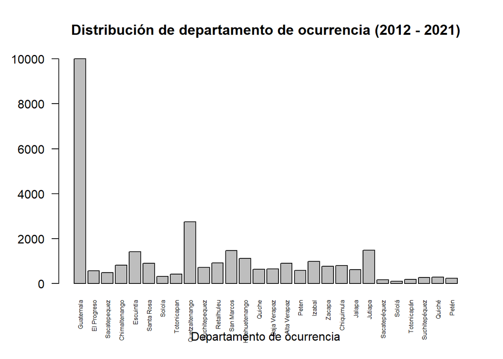

### Tabla de frecuencias para el municipio de ocurrencia

```
##
##                   Guatemala       Santa Catarina Pinula
##                        6367                         239
##             San José Pinula          San José del Golfo
##                         176                          34
##                    Palencia                   Chinautla
##                          79                         199
##           San Pedro Ayampuc                       Mixco
##                          95                         779
##      San Pedro Sacatepéquez       San Juan Sacatepéquez
##                         185                         131
##                San Raymundo                 Chuarrancho
##                          91                          19
##                   Fraijanes                   Amatitlán
##                          82                         356
##                 Villa Nueva               Villa Canales
##                         749                         314
##                      Petapa                  Guastatoya
##                         231                         206
##                     Morazán   San Agustín Acasaguastlán
##                          29                          58
## San Cristóbal Acasaguastlán                   El Jícaro
##                          16                          53
##                     Sansare                    Sanarate
##                          33                         107
##          San Antonio la Paz           Antigua Guatemala
##                          52                         262
##                 Jocotenango                    Pastores
##                          62                          19
##                    Sumpango       Santo Domingo Xenacoj
##                          18                           7
##       Santiago Sacatepéquez  San Bartolomé Milpas Altas
##                          30                          12
##      San Lucas Sacatepéquez    Santa Lucía Milpas Altas
##                          81                          41
##      Magdalena Milpas Altas        Santa María de Jesús
##                          19                           5
##                Ciudad Vieja           San Miguel Dueñas
##                          35                          15
##                  Alotenango San Antonio Aguas Calientes
```

[output cut: 284 more lines]

```
##                         114                           9
##                      Moyuta                      Pasaco
##                          91                           5
##           San José Acatempa                     Quesada
##                          81                          47
##         San José La Maquina                   La Blanca
##                           0                           8
##                     El Chal                   San Jorge
##                           6                           5
##                    Sipacate         San José la Maquina
##                           0                           4
##                     Petatán                  Extranjero
##                           0                           0
##                    Ignorado
##                           0
```

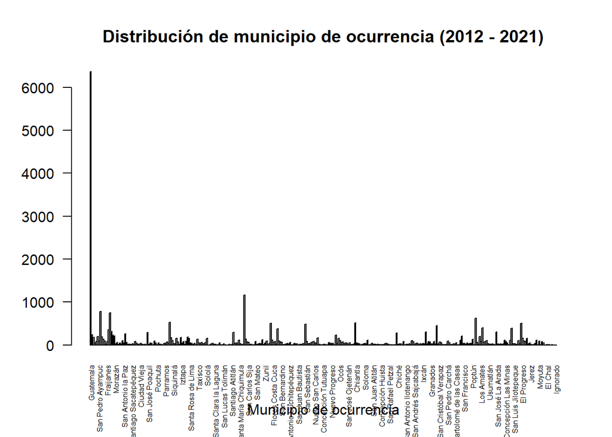

### Tabla de frecuencias para la escolaridad del hombre

```
##
##       Ninguna      Primaria        Básico Diversificado Universitario
##           318          4846          3138         10566          3149
##      Ignorado       Ninguno     Postgrado        Básica    Post Grado
##          5275          2752             7           280            47
##     Doctorado
##             0
```

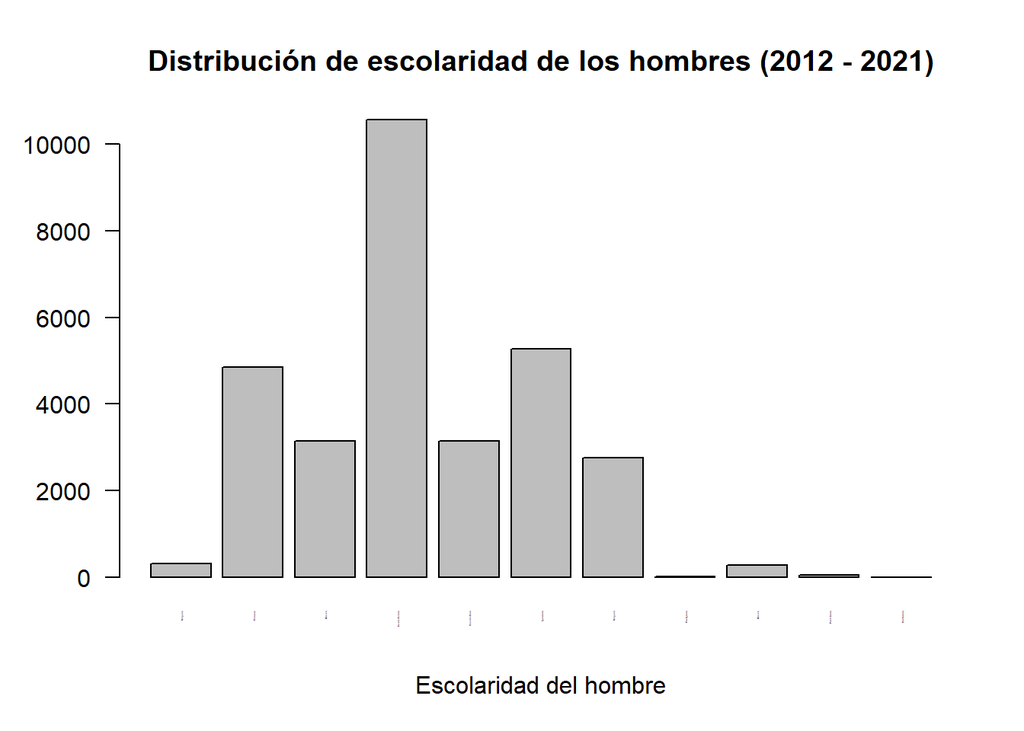

### Tabla de frecuencias para la escolaridad de la Mujer

```
##
##       Ninguna      Primaria        Básico Diversificado Universitario
##           347          5118          3439         11462          3082
##      Ignorado       Ninguno     Postgrado        Básica    Post Grado
##          3534          3074             4           289            29
##     Doctorado
##             0
```

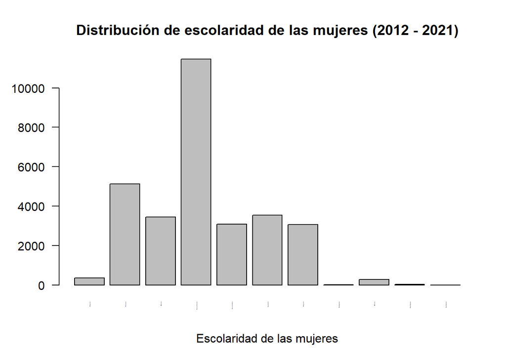

### Tabla de frecuencias para el grupo étnico del hombre

```
##
##         Garífuna         Ignorado         Indigena Ladino / Mestizo
##               18             6141              182            19355
##             Maya      No indigena             Otro            Xinka
##             3564              820              293                5
```

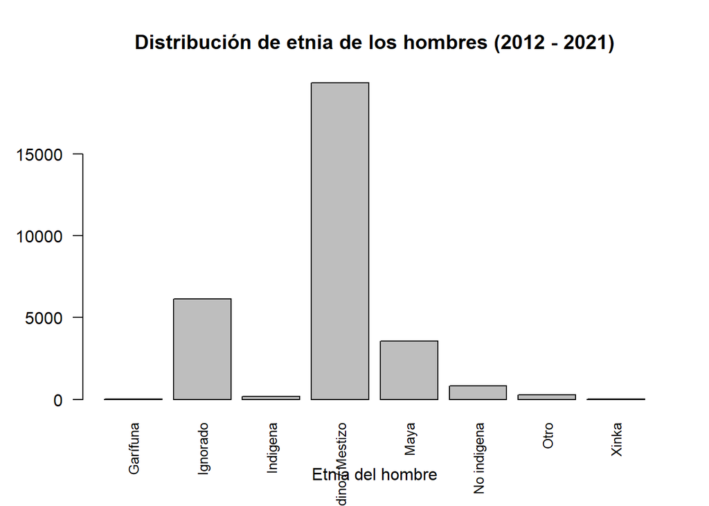

### Tabla de frecuencias para el grupo étnico de la mujer

```
##
##         Garífuna         Ignorado         Indigena Ladino / Mestizo
##               21             4740              192            20671
##             Maya      No indigena             Otro            Xinka
##             3401              987              363                3
```

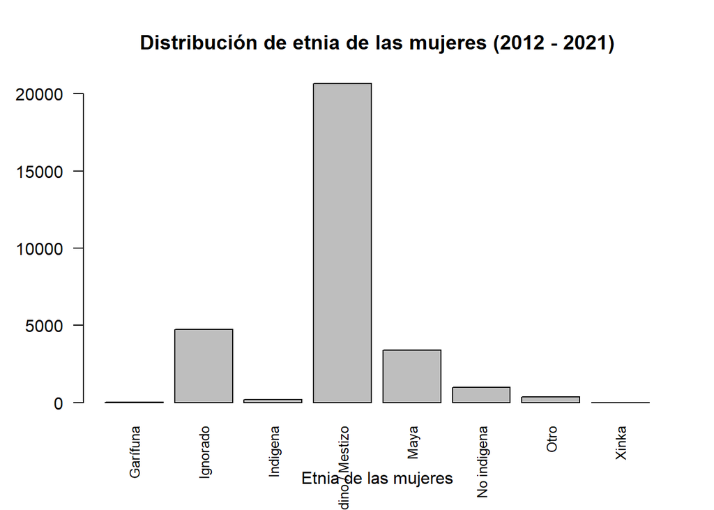